# Project 2

How does an individual’s lifestyle affect their sleep?

520476042, 520465367, 520637757, 520443804, 520326356, 520534353

# 1 Executive Summary

The aim of this report is to examine how an individuals lifestyle can affect their sleep. Correspondingly, this experiment discovered that there’s no correlation between an individuals lifestyle and how it affects their sleep. More research should be done with a wider range of individuals for further study.

# 2 Full Report

```r
library(tidyverse)
survey = read.csv("Data1001SurveyOriginal.csv")
str(survey)
```

```
## 'data.frame':    114 obs. of  10 variables:
##  $ Timestamp  : chr  "2022/09/01 11:34:24 am GMT+10" "2022/09/01 11:38:30 am GMT+10" "2022/09/01 11:39:18 am GMT+10" "2022/09/01 11:42:51 am GMT+10" ...
##  $ Age        : int  18 19 18 37 20 18 18 17 19 19 ...
##  $ Gender     : chr  "Male" "Male" "Male" "Male" ...
##  $ NoMeals    : int  4 2 3 3 3 3 4 3 3 2 ...
##  $ Occupation : chr  "Student;Casual" "Student;Unemployed" "Student;Part time / Full time;Casual" "Unemployed" ...
##  $ SleepLength: int  7 7 7 8 7 7 7 7 6 6 ...
##  $ TimeSleep  : chr  "2:00" "3:00" "0:10" "21:30" ...
##  $ EatMeals   : chr  "Breakfast;Lunch;Dinner" "Lunch;Dinner" "Breakfast;Lunch;Dinner" "Breakfast;Lunch;Dinner" ...
##  $ TakeoutNum : chr  "0-3" "0-3" "3-6" "0-3" ...
##  $ LastMeal   : chr  "Other" "7pm-9pm" "5pm-7pm" "5pm-7pm" ...
```

```r
head(survey)
```

```
##                       Timestamp Age Gender NoMeals
## 1 2022/09/01 11:34:24 am GMT+10  18   Male       4
## 2 2022/09/01 11:38:30 am GMT+10  19   Male       2
## 3 2022/09/01 11:39:18 am GMT+10  18   Male       3
## 4 2022/09/01 11:42:51 am GMT+10  37   Male       3
## 5 2022/09/01 11:47:08 am GMT+10  20   Male       3
## 6 2022/09/01 11:53:21 am GMT+10  18   Male       3
##                             Occupation SleepLength TimeSleep
## 1                       Student;Casual           7      2:00
## 2                   Student;Unemployed           7      3:00
## 3 Student;Part time / Full time;Casual           7      0:10
## 4                           Unemployed           8     21:30
## 5        Student;Part time / Full time           7     20:00
## 6                       Student;Casual           7      2:00
##                 EatMeals TakeoutNum LastMeal
## 1 Breakfast;Lunch;Dinner        0-3    Other
## 2           Lunch;Dinner        0-3  7pm-9pm
## 3 Breakfast;Lunch;Dinner        3-6  5pm-7pm
## 4 Breakfast;Lunch;Dinner        0-3  5pm-7pm
## 5 Breakfast;Lunch;Dinner        0-3  5pm-7pm
## 6 Breakfast;Lunch;Dinner        3-6  7pm-9pm
```

```r
dim(survey)
```

```
## [1] 114  10
```

```r
class(survey)
```

```
## [1] "data.frame"
```

## 2.1 Initial Data Analysis (IDA)

Source: The data was obtained through our survey, uploaded to social media between 01/09/2022 - 08/09/2022, resulting in a demographic of primarily university students.

Structure: Our data consisted of 5 quantitative (e.g. Sleep duration) and 4 qualitative variables (e.g. occupation), ranging from quantitative discrete and quantitative continuous to qualitative nominal and qualitative ordinal. There were 114 total responses.

Limitations: One of the biggest limitations was the selection bias that arose from distributing a survey favouring social media users, restricting the demographic. Most of our data was filled out by 17-22 year olds, thus the data cannot be generalised for the whole population. Consent bias resulted from people choosing to partake in the survey. As this study is observational, only correlations can be drawn. Outliers also existed.

Assumptions: People sleep at the same time, without much variation. Meals eaten don’t vary much. Last meal eaten each day is regular.

Survey: https://docs.google.com/forms/d/1Aq-gttcMkAY8MWvmpvCLnWAHEgUh-jSEIhycAj62dK8/edit?usp=sharing

## 2.2 How does lifestyle affect an individual’s sleep?

### 2.2.1 Does the number of meals affect sleep habits?

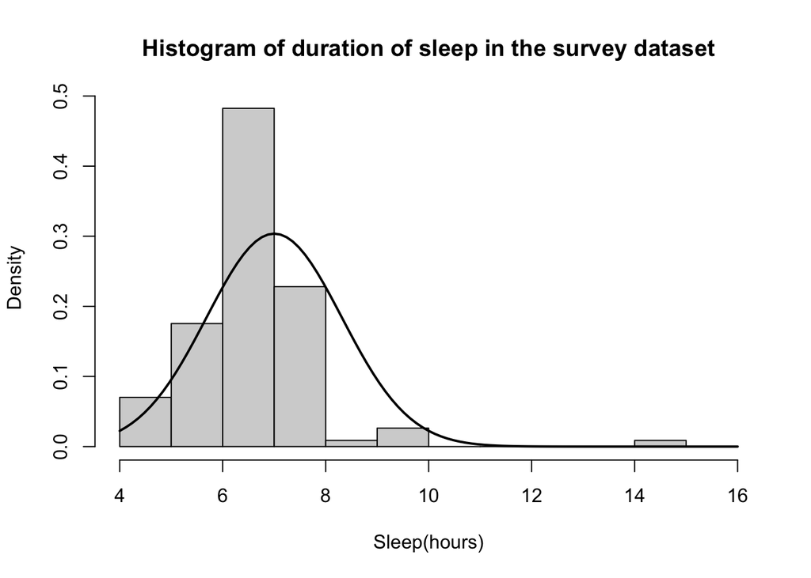

```r
survey = read.csv("Data1001SurveyOriginalHist.csv")
# construct the histogram
hist(x = survey$SleepLength,
     freq = FALSE, # use probability density
     xlab = "Sleep(hours)",
     main = "Histogram of duration of sleep in the survey dataset",
     xlim=c(4,16))
# then, add the curve
curve(dnorm(x, mean = mean(survey$SleepLength),
            sd = sd(survey$SleepLength)),
      col = "black",  # colour of line to black
      lwd = 2,        #thickness of line
      add = TRUE)     #if true we superimpose this line on top of our histogram
```

As seen in the histogram above, we have plotted a normal curve across the histogram, highlighting how sleep is relatively normally distributed, with the most common hours of sleep at around 7 hours.

```r
survey = read.csv("Data1001SurveyOriginal.csv")
cor(survey$NoMeals,survey$SleepLength)
```

```
## [1] NA
```

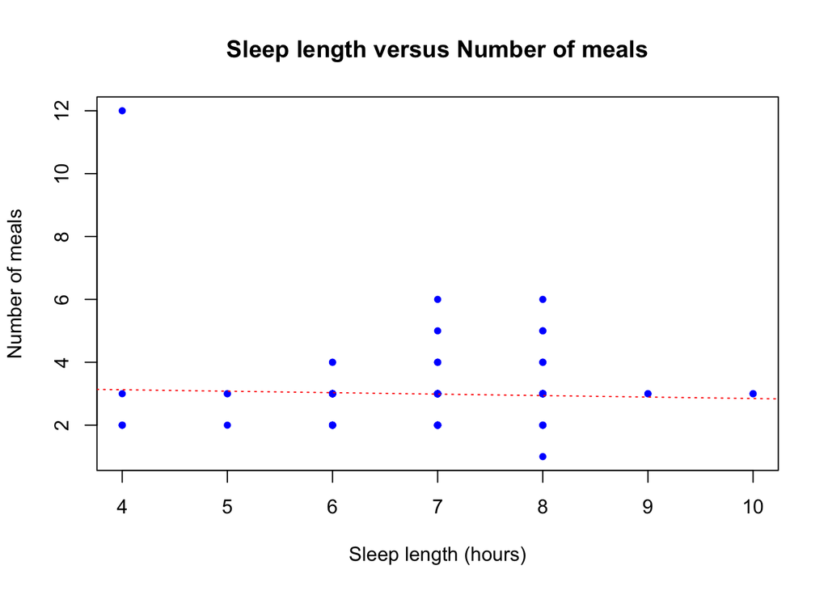

```r
survey = read.csv("Data1001SurveyOriginal.csv")
plot(survey$NoMeals~survey$SleepLength, xlab="Sleep length (hours)", ylab="Number of meals", main="Sleep length versus Number of meals", pch = 20, col="blue")
abline(lm(survey$NoMeals~survey$SleepLength), lty=3, col="red")
```

### 2.2.2 Does age affect sleeping habits?

```r
survey = read.csv("Data1001SurveyOriginal.csv")
cor(survey$Age,survey$SleepLength)
```

```
## [1] NA
```

Shown graphically:

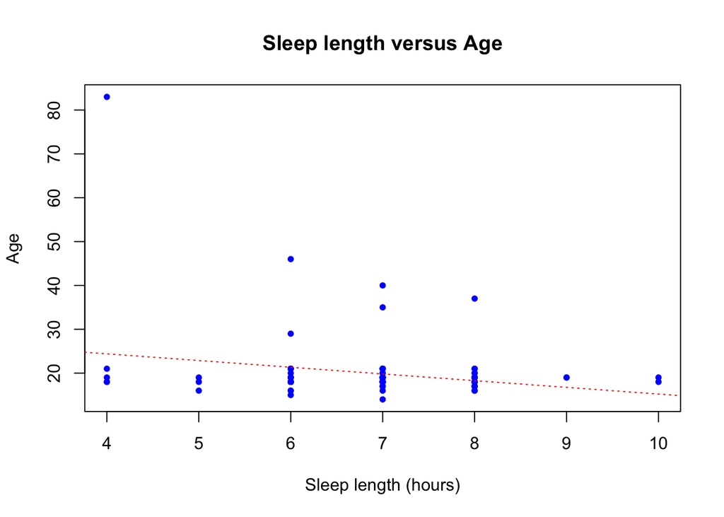

```r
survey = read.csv("Data1001SurveyOriginal.csv")
plot(survey$Age~survey$SleepLength, xlab="Sleep length (hours)", ylab="Age", main="Sleep length versus Age", pch = 20, col="blue")
abline(lm(survey$Age~survey$SleepLength), lty=3, col="red")
```

We can also explore the relationship between age and the average time of sleep

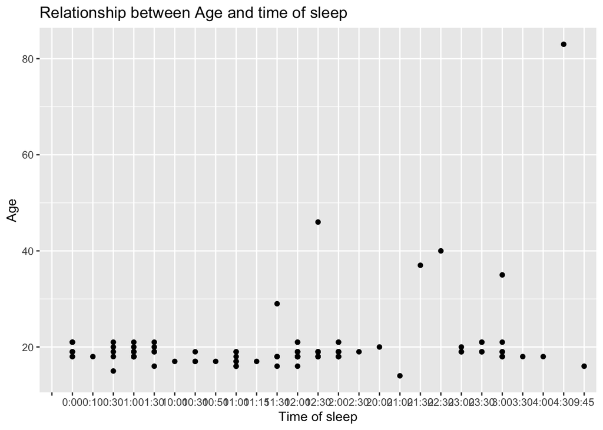

```r
ggplot(survey, aes(x = TimeSleep, y = Age)) +
  geom_point() +
  geom_smooth(method = "lm")  +
  xlab("Time of sleep") +
  ylab("Age") +
  ggtitle("Relationship between Age and time of sleep")
```

As seen above, there is also no correlation between age and time of sleep. Thus, from the data seen above, we can conclude that age has no effect on sleeping habits (length and time). However, we must consider the limitations of our data as they may not reflect wider population.

### 2.2.3 Does occupation affect sleeping habits?

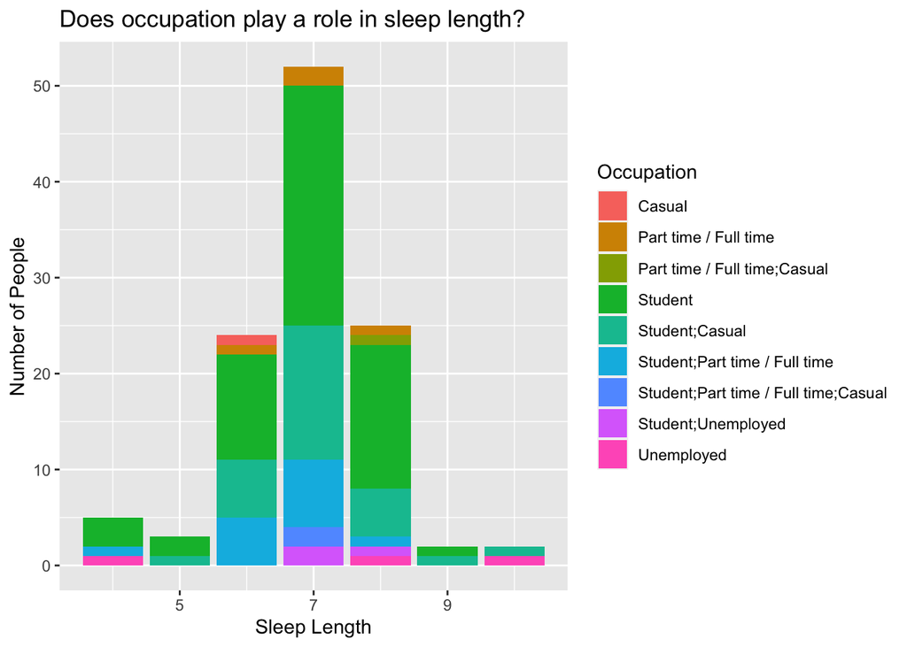

```r
ggplot(data = survey,aes(x = SleepLength)) + geom_bar(aes(fill = Occupation)) +

  labs(title = "Does occupation play a role in sleep length?",
       x = "Sleep Length" ,
       y = "Number of People",
       fill = "Occupation")
```

As a result of the graph above, the majority of people who took part in this survey have an average sleep duration of between 6 and 8 hours. On the whole, students as well as students doing casual jobs contributed to the majority.

### 2.2.4 Does take out habits affect sleep?

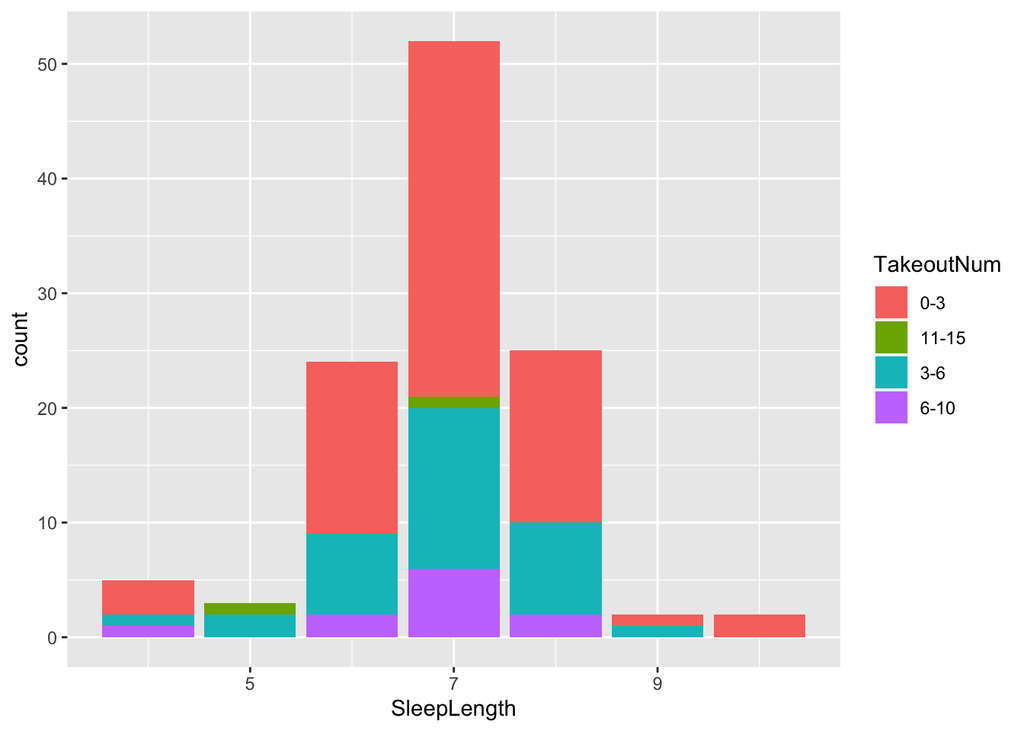

```r
ggplot(survey, aes(x = SleepLength, fill=TakeoutNum)) +
  geom_bar()
```

From this graph, there is a relatively even spread of the number of takeout across the range of sleep lengths. Thus, we can conclude that there is little to no correlation between the number of takeout per week and the average sleep length.

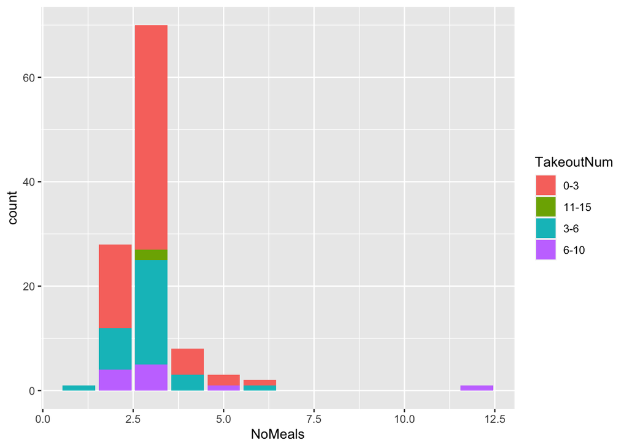

```r
ggplot(data=survey, aes(x=NoMeals, fill=TakeoutNum))+geom_bar()
```

The graph above highlights the relationship between the number of meals individuals consume and the amount of that in which is from takeout. There is an obvious trend that individuals usually only either have 0-3 times a week for takeout or 3-6 meals in takeout. Additionally, the most common number of meals each day is around 3 which is the normal amount for human beings.

## 2.4 References

Knudsen, H., Ducharme, L., & Roman, P. (2007). Job stress and poor sleep quality: Data from an American sample of full-time workers. Social Science &Amp; Medicine, 64(10), 1997-2007. doi: 10.1016/j.socscimed.2007.02.020 (https://www.ncbi.nlm.nih.gov/pmc/articles/PMC1933584/)

Chung, N., Bin, Y., Cistulli, P., & Chow, C. (2020). Does the Proximity of Meals to Bedtime Influence the Sleep of Young Adults? A Cross-Sectional Survey of University Students. International Journal Of Environmental Research And Public Health, 17(8), 2677. doi: 10.3390/ijerph17082677 (https://www.ncbi.nlm.nih.gov/pmc/articles/PMC7215804/)

The Effect of Eating Habits on Sleep Quality in 19-24 Years Old Young Adult Women. (2020). Intervention In Obesity & Diabetes, 3(5), 1-7. Retrieved from https://crimsonpublishers.com/iod/fulltext/IOD.000572.php

## 2.5 Acknowledgments

[output not shown]